# What has been the impact from air pollution on global health problems from 1990 to present?

Manunpat Sirijaturaporn, Derek Greiner, and Arturo García Luna Beltrán

14 November, 2021

# Introduction

We have chosen the theme of air pollution because global warming is a battle that will define our future as a species. Although more and more people from different backgrounds such as scientists, economists, or politicians are trying to prevent this crisis, no concrete amelioration has been registered so far. We believe that it is key to better understand the scope of air pollution’s impact on different metrics to realize the importance and emergency of the problem. We are especially interested in this, that this crisis affects multiple themes, such as health, nature, our economy, and its growth. However, for this project, we want to focus on the impact of air pollution on one of these, namely health.

While our research will focus on global issues as well as a cross-country analysis, we would like to use the fact that we come from 3 different countries (Mexico, Thailand, and Switzerland) to make a special focus on these countries when presenting results. These countries are very different in terms of development and growth, so we find it interesting to compare the different factors that affect air pollution in each of these places. Indeed, our countries being on 3 different continents, the different factors that affect air pollution can come from different sectors (agriculture, industries, …) and different geographical areas (north, south, plateau, mountain, etc.). If we are able to, we would like to make a special focus on these different factors when presenting our results.

- **Related Work**
- **Research questions**

#### 1. Descriptive Statistics

- 1.1 How have the air pollution levels changed from 1990 to 2019? How has mortality rate changed?
- 1.2 What are the diseases with a higher correlation with air pollution?
- 1.3 Does air pollution change with the seasons?

#### 2. Inferential Statistics

- 2.1 What are the factors that impact air pollution the most(GDP, geography, transportation, industry.)?
- 2.2 As a result of question 2.1, Are landlocked countries more polluted?
- 2.3 As a result of question 1.2, the variables “diseases” considered highly correlated with air pollution will be chosen for this question; What has been the effect of air pollution on some health diseases mortality?
- 2.4 What are the factors that impact air pollution the most in our respective countries? How do they compare with the continent they are in?

## Data

#### **Table 0 - ISO Country Codes**

Source:

IBAN.com is an authorized VocaLink Distributor: https://www.iban.com/country-codes

The table `iso_country_codes` contains the complete list of country names with their respective number and letter codes, to ease the identification of each country on the subsequent tables that form part of this analysis. In addition, the names of the countries described in this table will serve as the basis for all the others data sets to ensure that every country is labeled the same across all tables.

The columns were renamed to fit the information they were providing. The information related to the numerical codes in this table was deleted as we decided that we were going to use the ISO code because the other tables were also using it and thus did not need a second way of identifying each country.

We noticed that Kosovo (XKX) and Channel Islands(CHI) were lacking information not only in this table but also in all of the others and thus are not considered on the scope of this analysis. We can see in tables 3, 4 and 5 that CHI does not contain values across all the years. On the other hand, XKX only has partial information in table 4 (2000 to 2005) and 5 (2006 to 2016) and none in table 3.

The original iso_country_codes table

| Country | Alpha.2.code | Alpha.3.code | Numeric |
| --- | --- | --- | --- |
| Afghanistan | AF | AFG | 4 |
| Albania | AL | ALB | 8 |
| Algeria | DZ | DZA | 12 |
| American Samoa | AS | ASM | 16 |
| Andorra | AD | AND | 20 |

After selecting only relevant variables

| Country.Name | Country.Code2 | Country.Code3 |
| --- | --- | --- |
| Afghanistan | AF | AFG |
| Albania | AL | ALB |
| Algeria | DZ | DZA |
| American Samoa | AS | ASM |
| Andorra | AD | AND |

#### **Table 1 - Global Mortality Rate - Air Pollution**

Source:

Global Burden of Disease Collaborative Network. Global Burden of Disease Study 2019 (GBD 2019) Results. Seattle, United States: Institute for Health Metrics and Evaluation (IHME), 2020. Available from: http://ghdx.healthdata.org/gbd-results-tool

The table `mortality rate` contains the overall rate of deaths from various diseases worldwide, where the main risk factor was ambient particulate matter pollution between 1990 and 2019. It considers all ages and both sexes. There are 19 different diseases taken into account and the metric used is a rate per 100k deaths.

In this table, some columns containing numeric values were seen as characters so they had to be converted to numeric in order to be worked on. Then, the values were rounded, the columns renamed and the table reshaped for clarity purposes.

We also created a table containing the five most deadly diseases across all years. The table will help our analysis later on this report.

Identifying the deadliest diseases caused by air pollutants (E.g. 1990-1998)

| measure | location | sex | age | cause | metric | Total | 1990 | 1991 | 1992 | 1993 | 1994 | 1995 | 1996 | 1997 | 1998 |
| --- | --- | --- | --- | --- | --- | --- | --- | --- | --- | --- | --- | --- | --- | --- | --- |
| Deaths | Global | Both | All Ages | Ischemic heart disease | Rate | 411 | 11.36 | 11.41 | 11.52 | 11.84 | 12.01 | 11.98 | 11.91 | 11.93 | 11.95 |
| Deaths | Global | Both | All Ages | Chronic obstructive pulmonary disease | Rate | 235 | 6.58 | 6.69 | 6.82 | 6.96 | 7.04 | 7.09 | 7.20 | 7.35 | 7.48 |
| Deaths | Global | Both | All Ages | Intracerebral hemorrhage | Rate | 184 | 4.35 | 4.40 | 4.49 | 4.62 | 4.74 | 4.83 | 4.97 | 5.14 | 5.33 |
| Deaths | Global | Both | All Ages | Ischemic stroke | Rate | 158 | 4.22 | 4.24 | 4.30 | 4.44 | 4.52 | 4.53 | 4.53 | 4.55 | 4.59 |
| Deaths | Global | Both | All Ages | Lower respiratory infections | Rate | 136 | 5.43 | 5.32 | 5.23 | 5.13 | 5.02 | 4.91 | 4.80 | 4.75 | 4.71 |

#### **Table 2 - Mortality Rate by Country - Air Pollution**

Source:

Global Burden of Disease Collaborative Network. Global Burden of Disease Study 2019 (GBD 2019) Results. Seattle, United States: Institute for Health Metrics and Evaluation (IHME), 2020. Available from: http://ghdx.healthdata.org/gbd-results-tool

The table `mortality rate per country` contains the overall rate of deaths from various diseases per country, where the main risk factor was ambient particulate matter pollution, between 1990 and 2019. It considers all ages and both sexes. There are 19 different diseases taken into account and the metric used is a rate per 100k deaths.

Examples from the original table (select only location, cause, year, and val)

| location | cause | year | val |
| --- | --- | --- | --- |
| Haiti | Diabetes mellitus type 2 | 1990 | 0.538 |
| Tonga | Intracerebral hemorrhage | 1990 | 1.233 |
| Cambodia | Upper respiratory infections | 1990 | 0.000 |
| Slovakia | Sudden infant death syndrome | 1990 | 0.002 |
| Samoa | Intracerebral hemorrhage | 1990 | 2.896 |

First, We would like to assign ISO country codes into the `mortality_rate_country` table, to make sure that we will be analyzing the same countries in every table, so we joined the table with the `iso_country_codes` table by country name.

Then, we checked for missing or mismatching values by creating a sub-table and found out that 27 countries from `mortality_rate_country` did not match the `iso_country_codes from`.

Examples of countries that cannot be found in the iso_country_codes table (27 countries in total)

|  | location | Country.Code2 | Country.Code3 |
| --- | --- | --- | --- |
| 13 | Russian Federation | NA | NA |
| 23 | Dominican Republic | NA | NA |
| 46 | North Macedonia | NA | NA |
| 66 | Philippines | NA | NA |
| 78 | Lao People’s Democratic Republic | NA | NA |

We found out that the vast majority of N/A values were caused by country names written differently.

e.g. In the `mortality_rate_country` table RUS is written “Russian Federation” but in the `iso_country_codes` table, RUS is written “Russian Federation (the)”.

There was also an issue related to a font error where CIV (Côte d’Ivoire) in the `iso_country_codes` was written as “CÃ´te d’Ivoire” in `mortality_rate_country`.

To fix these issues, we created a sub-table to match the countries that were creating N/A values with their proper ISO codes. Afterward, we used this sub-table to assign the correct ISO codes to the countries in the `mortality_rate_country` table.

Examples from the exception table created for fixing the naming issues

| iso_name | na_name | Country.Code2 | Country.Code3 |
| --- | --- | --- | --- |
| Côte d’Ivoire | CÃ´te d’Ivoire | CI | CIV |
| Russian Federation (the) | Russian Federation | RU | RUS |
| Dominican Republic (the) | Dominican Republic | DO | DOM |
| Republic of North Macedonia | North Macedonia | MK | MKD |
| Philippines (the) | Philippines | PH | PHL |

Once the ISO codes were correctly assigned, we renamed the columns and restructured the table to have each disease in a column. Then, we created the ‘Total’ column which shows the total number of deaths from every disease per country, per year.

Examples from the final output for mortality rate by country

| location | Country.Code3 | year | Total | Diabetes mellitus type 2 | Intracerebral hemorrhage | Upper respiratory infections | Sudden infant death syndrome | Chronic obstructive pulmonary disease | Otitis media | Meningitis |
| --- | --- | --- | --- | --- | --- | --- | --- | --- | --- | --- |
| Haiti | HTI | 1990 | 11.27 | 0.538 | 1.55 | 0 | 0.002 | 0.672 | 0.001 | 0.052 |
| Tonga | TON | 1990 | 9.81 | 1.305 | 1.23 | 0 | 0.001 | 1.388 | 0.000 | 0.010 |
| Cambodia | KHM | 1990 | 14.80 | 0.234 | 1.48 | 0 | 0.005 | 0.784 | 0.002 | 0.011 |
| Slovakia | SVK | 1990 | 109.00 | 2.726 | 8.87 | 0 | 0.002 | 2.984 | 0.000 | 0.003 |
| Samoa | WSM | 1990 | 14.57 | 1.160 | 2.90 | 0 | 0.001 | 2.228 | 0.000 | 0.002 |

#### **Table 3 - Pollutant PM2.5**

Source:

[<https://databank.worldbank.org/reports.aspx?dsid=2&series=EN.ATM.PM25.MC.M3>](https://databank.worldbank.org/reports.aspx?dsid=2&series=EN.ATM.PM25.MC.M3)

The table `Airpol` shows the mean annual exposure of particulate matter2.5 (PM2.5) per country between 1990 and 2017. PM2.5 are particles with a diameter of fewer than 2.5 microns which means particles that are smaller than 0,0025 millimeters. Air pollution is measured in micrograms per cubic meter.

First, we removed the empty columns or the ones with information that are not relevant for our analysis. Afterward, some columns were containing numeric values that were seen as characters, so we changed them back to numeric values so we could work on them. Values were also rounded for clarity purposes.

When joining `Airpol` and `iso_country_codes`, we noticed that the only missing countries in `Airpol` are Kosovo(XKX) and the Channel Islands(CHI), and thus we will not consider them in the analysis so we excluded them from this table.

We also discovered that 55 countries were missing values for the years 1990 to 2017, so we decided not to include them in the final `Airpol` table. We created a sub-table called `missing_data_airpol` containing all missing countries.

Some countries will also display N/A values when joining them with other tables (4 and 5). We created another sub-table called `airpol.missing.countries` which contains the list of the 14 countries that will be missing.

| Country.Name | Country.Code | 1990 | 1995 | 2000 | 2005 | 2010 | 2011 | 2012 | 2013 | 2014 | 2015 | 2016 | 2017 |
| --- | --- | --- | --- | --- | --- | --- | --- | --- | --- | --- | --- | --- | --- |
| Afghanistan | AFG | 65.5 | 65.2 | 64.9 | 64.5 | 65.2 | 66.8 | 66.0 | 61.4 | 59.0 | 61.3 | 56.3 | 56.9 |
| Albania | ALB | 22.7 | 22.0 | 22.0 | 21.6 | 21.3 | 22.8 | 20.6 | 19.9 | 18.9 | 19.5 | 18.2 | 18.2 |
| Algeria | DZA | 36.9 | 36.5 | 37.5 | 35.9 | 33.6 | 33.8 | 33.4 | 34.2 | 35.6 | 36.1 | 39.9 | 38.9 |
| American Samoa | ASM | 12.5 | 12.5 | 15.2 | 15.2 | 15.1 | 15.4 | 14.3 | 14.1 | 13.3 | 13.0 | 12.4 | 12.5 |
| Andorra | AND | 14.1 | 13.9 | 12.6 | 13.0 | 12.8 | 13.3 | 12.4 | 11.8 | 10.8 | 11.5 | 10.3 | 10.3 |

#### **Table 4 - GDP - Factor of Air Pollution**

Source:

International Comparison Program, World Bank | World Development Indicators database, World Bank | Eurostat-OECD PPP Programme.

https://data.worldbank.org/indicator/NY.GDP.PCAP.PP.CD

The table `gdp` contains the GDP per capita per country based on purchasing power parity (PPP). PPP GDP is gross domestic product converted to international dollars using purchasing power parity rates, the information of the table runs from 1990 to 2020. Indicator Code: *NY.GDP.PCAP.PP.CD* Indicator Name: *GDP per capita, PPP (current international $)*

First, we deleted the columns that were not relevant for our analysis and renamed them for clarity purposes.

We realized when joining `gdp` and `iso_country_codes` that the data set included locations that were not countries but continents or regions (e.g. “British Virgin Islands”). As our analysis for this table focuses on individual countries, we will not take these locations into account. We created a sub-table that contains a list of all these locations. Furthermore, we also removed Kosovo (XKX) and Channel Islands (CHI) for the reasons we mentioned earlier.

Just like the previous table, we found that several countries (52) had missing values. For that reason, we decided to not consider them in the final table for GDP. We created a sub-table containing the countries that were lacking values `missing_data_gdp`. There are also countries that will display N/A values when joining them with other tables (3 and 5), so we created a sub-table called `gdp.missing.countries` which contain the list of the 11 countries that will be missing.

First 5 rows from GDP Final Table (E.g. 1990-2001)

|  | Country.Name | Country.Code | 1990 | 1991 | 1992 | 1993 | 1994 | 1995 | 1996 | 1997 | 1998 | 1999 | 2000 | 2001 |
| --- | --- | --- | --- | --- | --- | --- | --- | --- | --- | --- | --- | --- | --- | --- |
| 1 | Afghanistan | AFG | NA | NA | NA | NA | NA | NA | NA | NA | NA | NA | NA | NA |
| 2 | Albania | ALB | 2549 | 1909 | 1823 | 2057 | 2289 | 2665 | 2979 | 2717 | 3021 | 3472 | 3862 | 4301 |
| 3 | Algeria | DZA | 6916 | 6893 | 7010 | 6871 | 6812 | 7083 | 7378 | 7466 | 7817 | 8068 | 8447 | 8775 |
| 6 | Angola | AGO | 3281 | 3314 | 3089 | 2327 | 2332 | 2651 | 2968 | 3137 | 3215 | 3226 | 3289 | 3389 |
| 7 | Antigua and Barbuda | ATG | 11594 | 12087 | 12293 | 12983 | 13846 | 13230 | 14054 | 14757 | 15307 | 15789 | 16843 | 16173 |

#### **Table 5 - Agriculture - Factor of Air Pollution**

Source:

World Bank national accounts data, and OECD National Accounts data files.

https://databank.worldbank.org/source/jobs/Type/TABLE/preview/on

The table `agriculture` shows the value added by the agricultural sector to the GDP for each country between 1990 and 2016. The metric used is a percentage of the GDP.

We started by deleting empty columns, renaming them, and transforming characters’ values into numeric ones when needed.

Just like the other tables, we will not consider Kosovo (XKX) and Channel Islands (CHI) and exclude them from this table.

Just like the previous tables, we found that several countries (52) had missing values. For that reason, we decided to not consider them in the final table for `agriculture`. We created a sub-table containing the countries that were lacking values `missing_data_agri`. There are also countries (11) displaying N/A values when joining them with other tables (3 and 4), so we created a sub-table called `agri.missing.countries` to identify them.

First 5 rows from Agriculture Final Table (E.g. 1990-2001)

|  | Country.Name | Country.Code | 1990 | 1991 | 1992 | 1993 | 1994 | 1995 | 1996 | 1997 | 1998 | 1999 | 2000 | 2001 |
| --- | --- | --- | --- | --- | --- | --- | --- | --- | --- | --- | --- | --- | --- | --- |
| 1 | Afghanistan | AFG | NA | NA | NA | NA | NA | NA | NA | NA | NA | NA | NA | NA |
| 2 | Albania | ALB | 35.9 | 39.30 | 51.64 | 54.6 | 53.62 | 55.81 | 35.15 | 30.19 | 27.1 | 24.39 | 23.499 | 21.948 |
| 3 | Algeria | DZA | 10.4 | 9.22 | 11.20 | 11.2 | 9.23 | 9.54 | 10.81 | 8.73 | 11.5 | 11.11 | 8.395 | 9.749 |
| 5 | Andorra | AND | NA | NA | NA | NA | NA | NA | NA | NA | NA | NA | 0.488 | 0.459 |
| 6 | Angola | AGO | 16.4 | 28.57 | 7.89 | 10.5 | 6.08 | 6.65 | 7.03 | 9.00 | 12.9 | 6.29 | 5.665 | 8.156 |

#### **Table 6 - Landlocked Countries**

Source:

Geography Realm website | The editor, Caitlin Dempsey can be reached via e-mail at editor@geographyrealm.com or via physical mail at 1200 Franklin Mall # 524, Santa Clara CA 95052 USA.

https://www.geographyrealm.com/landlocked-countries/

The table `landlocked_countries` is a list of all countries that are considered landlocked as of July 2017. A country is considered landlocked if it is surrounded by at least one other country which means it has no direct access to any coastline which means no direct access to any oceans / seas. This table includes 5 partially recognized states.

We assigned ISO country codes into the`landlocked_countries` table and we found that there were 14 countries (out of 49 landlocked countries) whose names did not match with the ISO country names. We applied the same strategy we used in table 2: we created a sub_table to fix the mismatching issue and then replaced them in the `landlocked_countries` table.

After replacing the ISO-standard country names in the table, we found that there are still 7 countries that have no ISO country codes

Examples from the original table

| Country.or.Territory | Area.km2. | Surrounding.countries | Number.of.Surrounding.Countries |
| --- | --- | --- | --- |
| Afghanistan | 652,230 | Iran, Turkmenistan, Uzbekistan, Tajikistan, China, Pakistan | 6 |
| Andorra | 468 | France, Spain | 2 |
| Armenia | 29,743 | Iran, Turkey, Georgia, Azerbaijan | 4 |
| Austria | 83,871 | Germany, Czech Republic, Slovakia, Hungary, Slovenia, Italy, Liechtenstein, Switzerland | 8 |
| Azerbaijan | 86,600 | Russia, Georgia, Armenia, Iran, Turkey | 4 |

7 landlocked countries that have no ISO country codes

|  | Country.or.Territory | Country.Code3 | Surrounding.countries |
| --- | --- | --- | --- |
| 18 | Kosovo | NA | Albania, Macedonia, Montenegro, Serbia |
| 29 | Artsakh | NA | Armenia, Azerbaijan, Iran |
| 37 | South Ossetia | NA | Georgia, Russia |
| 39 | Swaziland | NA | Mozambique, South Africa |
| 42 | Transnistria | NA | Moldova, Ukraine |
| 46 | Vatican City | NA | Italy |
| 47 | West Bank | NA | Israel, Jordan |

#### **Table 7 - 19 - Air Quality Pollution Levels**

Source:

Air Quality Open Data Platform | The World Air Quality Index project | Worldwide COVID-19 dataset

https://aqicn.org/data-platform/covid19/verify/f042745e-a7a1-4c10-b98d-13c6b69bcc2d

These tables contain information about the overall air quality in 380 cities worldwide from 2015 to 2020. The data set provides a wide variety of information such as min, max, etc. for each air pollutant species (PM2.5, PM10, etc.) as well as meteorological data (wind, temperature, …). the years 2019 and 2020 are divided quarterly. PM2.5 and PM10 are measured in $\mu g/x^{3}$. O3, SO2, and NO2 are measured in ppm (parts per million).

First, we assigned numeric values when it was needed and restructured the table for clarity purposes.

There are 12 files for each quarter/semi-annual from 2015 to 2020, so we run a for loop and use the rbind function to aggregate the data from all sources into 1 table.

The original data sources reported daily air pollution data in cities around the world. However, our study focuses on air pollution at a national level, so we calculate average daily air pollution data for each country.

We stored the output in the `airquality_daily` table which contains 3 variables, data, country (Alpha-Code2), and Averagepm25. We then joined with the `iso_country_codes` table and added country names and Country.Code3, which is the 3 letters ISO Code, in the table.

We checked if Country.Code3 had any N/A and found that there were 1230 N/A, which were from only 1 country: Kosovo (XKX). Since Kosovo is not in the scope of our study, we removed Kosovo from the table.

Subsequently, we converted the daily air pollution data to seasonality by averaging the air pollution data for each month.

Examples from the airquality_daily table

| Date | Country.Name | Country.Code3 | Averagepm25 | Averageco | Averagepm10 | Averageo3 | Averageso2 | Averageno2 |
| --- | --- | --- | --- | --- | --- | --- | --- | --- |
| 2014-12-29 | Austria | AUT | 69.5 | 0.10 | 20.8 | NaN | 2.00 | 15.78 |
| 2014-12-29 | Australia | AUS | 18.2 | 2.33 | 11.7 | 13.17 | 3.32 | 4.31 |
| 2014-12-29 | Belgium | BEL | 65.7 | 0.10 | 24.0 | 5.67 | 1.80 | 19.42 |
| 2014-12-29 | Bolivia (Plurinational State of) | BOL | NaN | NaN | 25.0 | 4.30 | NaN | 3.00 |
| 2014-12-29 | Brazil | BRA | 50.0 | 5.50 | 20.5 | 19.70 | 1.10 | 12.40 |

Examples from the airquality_season table

| month | Country.Name | MonthlyAveragepm25 | MonthlyAverageco | MonthlyAveragepm10 | MonthlyAverageo3 | MonthlyAverageso2 | MonthlyAverageno2 |
| --- | --- | --- | --- | --- | --- | --- | --- |
| 01 | Afghanistan | 143.5 | NA | NA | NA | NA | NA |
| 01 | Algeria | 79.7 | NA | NA | NA | NA | NA |
| 01 | Argentina | 44.2 | 2.41 | 19.7 | 12.8 | 2.85 | 7.11 |
| 01 | Australia | 29.9 | 3.52 | 19.2 | 22.1 | 3.32 | 13.38 |
| 01 | Austria | 63.2 | 0.10 | 23.3 | NA | 1.88 | 18.46 |

## Exploratory data analysis

#### **Table 1 - Global Mortality Rate - Air Pollution**

The most important variables in this table will be the number of deaths of each disease by year globally (per 100k population). This variable will be used to know which are the deadliest diseases caused by particulate matter pollution, and to determine which ones are correlated with air pollution.

From the chart, we can visualize a constant increment of mortality rates across the years by most of the diseases with Ischemic heart disease above of them, while the Lower respiratory diseases seem to go down through the years.

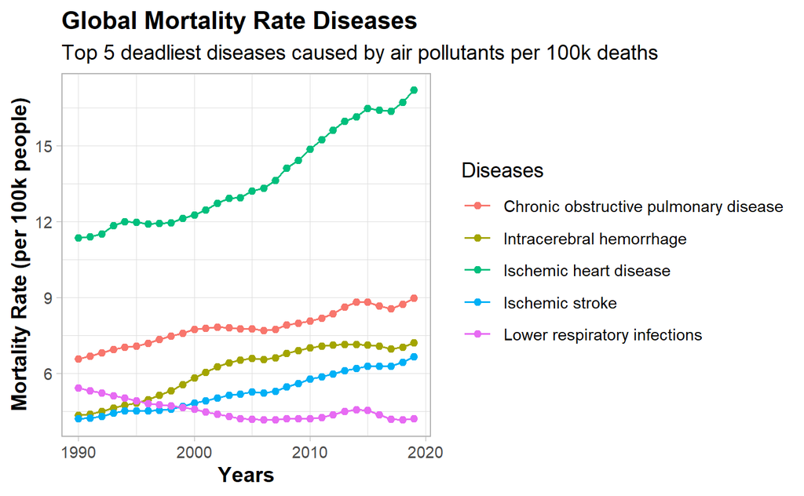

#### **Table 2 - Mortality Rate by Country - Air Pollution**

The most important variables are `Total` and the death rate of each disease. `Total` represents the total death rate (per 100k population) in each country by year. These variables will be used to study how mortality rates around the world have changed.

The death rate of each disease will be used to study the correlation/regression analysis of diseases and outdoor air pollution levels. We will study the mortality rates of which diseases are correlated with air pollution the most.

We generated this chart by calculating the distribution (min, 25th percentile, mean, 75th percentile, and max) of the total mortality rate per year.

From the chart, we can see that ranges between the min and 75th percentile are quite narrow (between 0 and 50 deaths per 100k population) while, the max rate is significantly higher (over 125 deaths per 100k population).

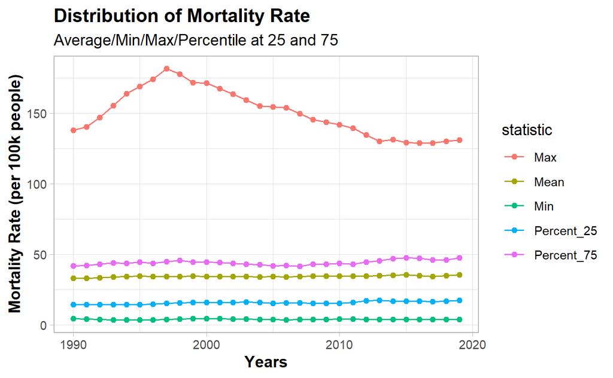

Regarding the distribution of mortality rates, it leads us to see which countries have the highest death rates. Therefore, we created the top 10 countries with the highest mortality rates.

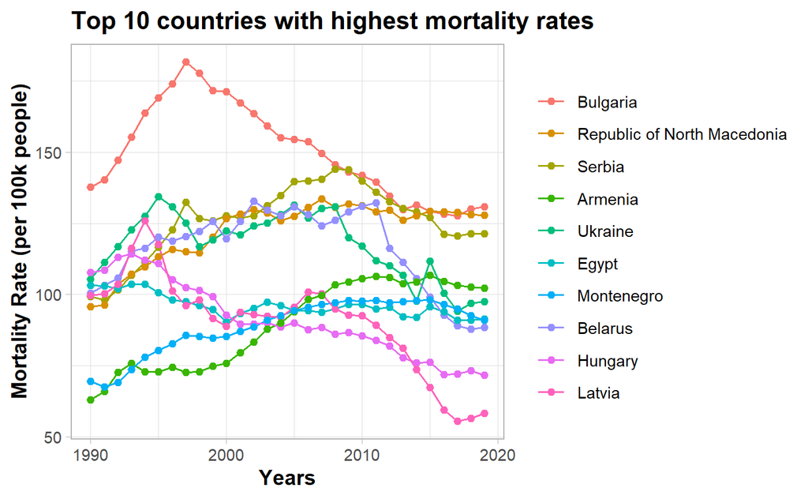

This section is the summary of our data statistics in 1990 and 2019. Most of the statistics increased except for the min and max.

```
#> Statistics of total death rate by country in 1990
#>    Min. 1st Qu.  Median    Mean 3rd Qu.    Max.
#>     4.4    14.5    25.1    33.0    41.7   137.7
#> Statistics of total death rate by country in 2019
#>    Min. 1st Qu.  Median    Mean 3rd Qu.    Max.
#>     3.8    17.5    30.1    35.5    47.5   130.8
```

The below world maps represent the death rate by country in 1990 and 2019 respectively. We can see that mortality rates in developed countries in 2019 tend to be lower than the rates in 1990, while the rates in Asian countries tend to increase.

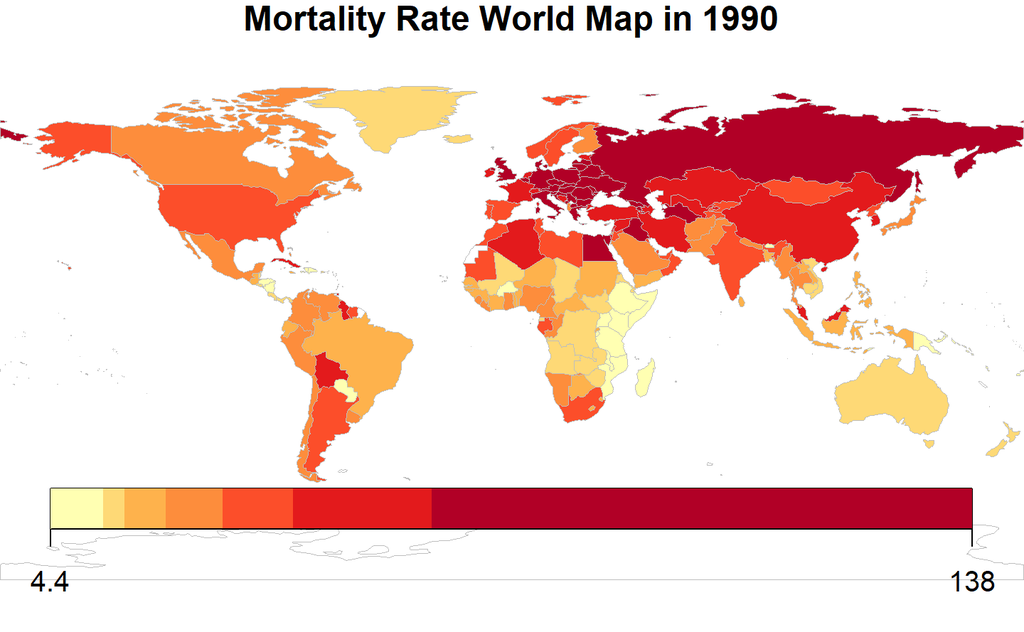

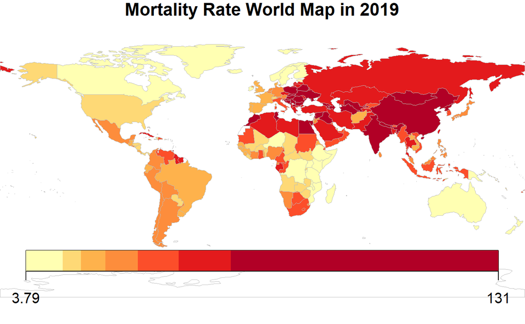

#### **Table 3 - Pollutant PM2.5**

The goal of this table is to understand the evolution of air pollution on a global scale, represented by the pollutant PM2.5 in our case. While there are details for every country, what interests us most in the first place is to see it globally. Thus, the most important variable in this table is the amount of PM2.5 ($\mu g/x^{3}$). This variable will be used to study the correlation between air pollution and health, as well as to study what factors cause air pollution.

To do so we first compute the statistics for every year we consider. Once we have the statistics for every year, We plot time series of the statistics to see the evolution of air pollution over the years. This graph will be compared with the previous table to see if the evolution of air pollution is positively correlated with the evolution of the mortality rate.

From the chart, we can see that the max value is very high even compared to the 75% percentile. It means that some countries have way more air pollution than the majority.

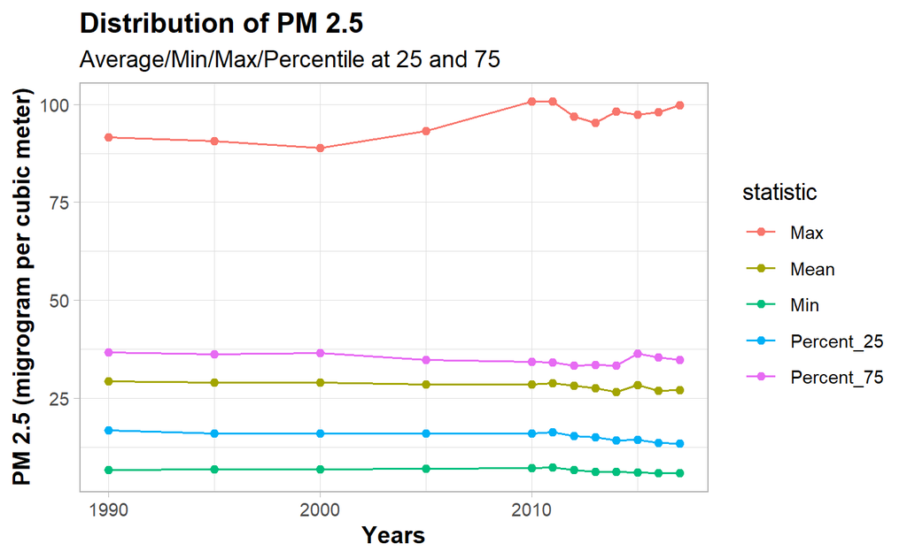

Then, we created the top 10 countries with the highest PM2.5 levels. From this chart, we can see that most of them are from South Asia and the Middle East. It will be interesting to compare if the top 10 countries with the highest PM2.5 level is similar to the top 10 countries with the highest mortality.

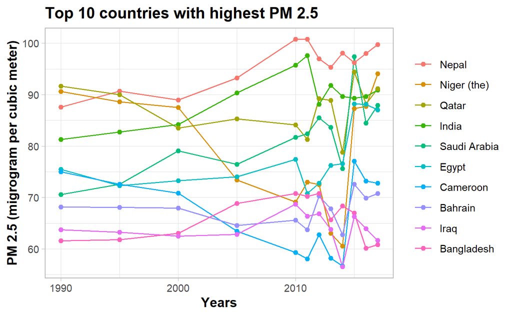

#### **Table 4 - GDP - Factor of Air Pollution**

The most important variables in this table would be the `Country.Name` and the values on each year, because the name of the country will be the key among the other tables, and the value will determine if a country has a high or low GDP.

The goal of this tables is to identify which countries are the ones with the highest and lowest GDP per capita, so later we can relate if the factor of a higher or lower GDP could have a direct impact on air pollution levels.

We then compute the statistics for each year and plot the time series to see the evolution over time. We can observe that the countries above the 75th percentile are much richer than the rest of the world.

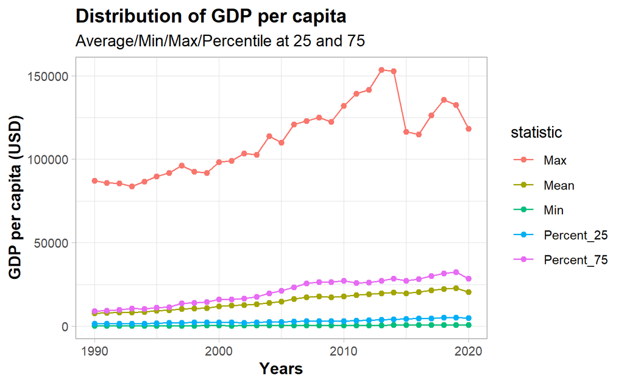

From the below chart, we can visualize that the top countries of the table with the highest GDP are developed countries where the per capita value is around 40,000 to 120,000 USD.

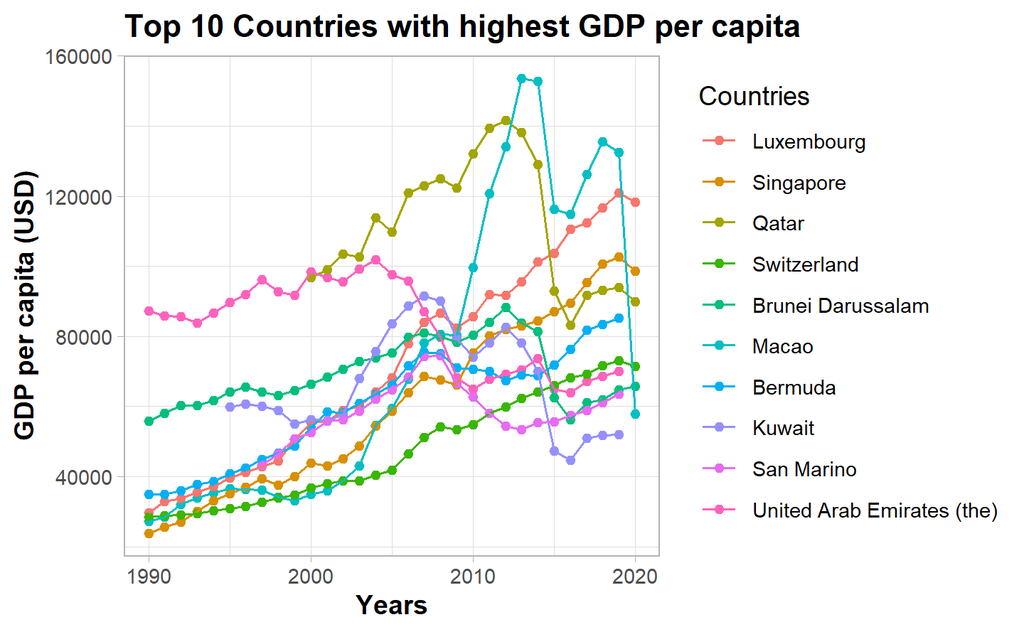

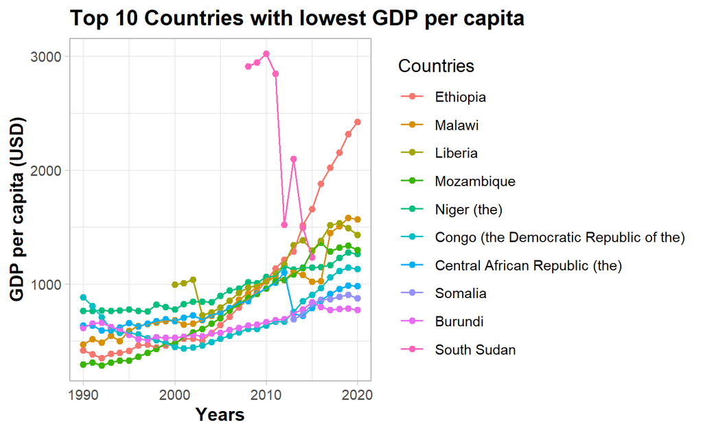

#### **Table 5 - Agriculture - Factor of Air Pollution**

This table helps us understand the impact of the agricultural sector on air pollution. The most important variable in this table is the proportion of agriculture in the GDP by year of each country. In the first place, this information will help to understand whether a country that is heavily based on agriculture has higher GDP. Furthermore, this data will be used to find out whether a high dependence on agriculture is positively correlated with a higher increase in air pollution.

We then computed the statistics for each year and plot the time series. We found that the % Agriculture of GDP tends to be decreasing.

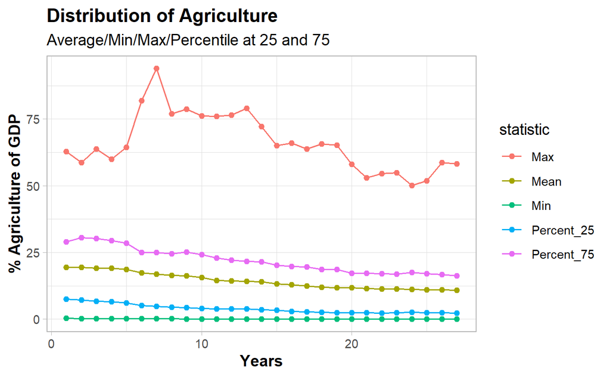

For clarity, we have made a graph showing the 10 countries most dependent on agriculture (the largest share of GDP). Among these 10 countries, Somalia had only 1 data point in 1990 and the last data point of Comoros was missing. In 1996, over 90% of Liberia’s GDP was from Agriculture but the number has decreased to lower than 40% in 2016.

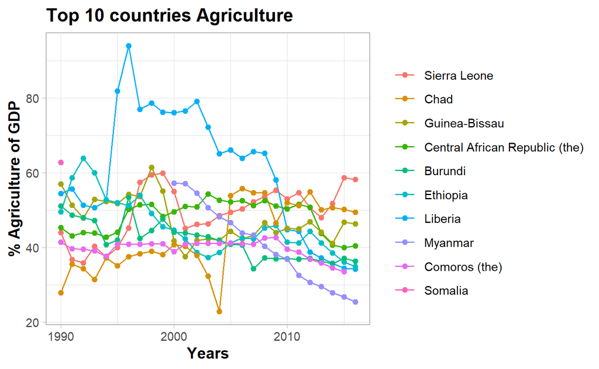

#### **Table 6 - Landlocked Countries**

We will create a dummy variable for landlocked countries to study the relationship between landlocked countries and air pollution levels. Our hypothesis is that landlocked countries tend to have higher air pollution levels due to lower airflow.

The below world map presents the landlocked countries in red and the rest is in gray.

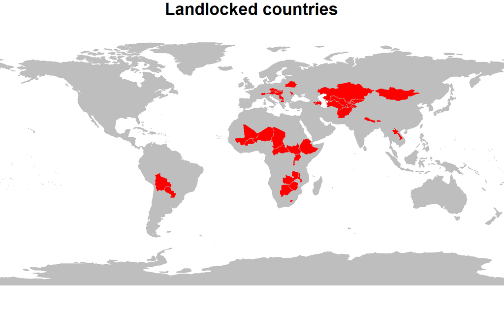

#### **Table 7 - 19 - Air Quality Pollution Levels**

The most important variables are seasonality data of air pollutants (6 variables for 6 pollutants). These variables will be used to study if air pollution changes with the seasons.

We created box plots for all six pollutants to show the distributions of air pollution levels around the world for each month. We observed a strong seasonality trend in PM2.5, SO2, and O3; PM2.5 and SO2 tend to be higher around between November to February and be lower in April to September while O3 has an inverse trend. For SO2, we spotted outliers in February and March. Regarding the other air pollutants, PM10, CO, and NO2, their seasonality patterns seem to be weaker.

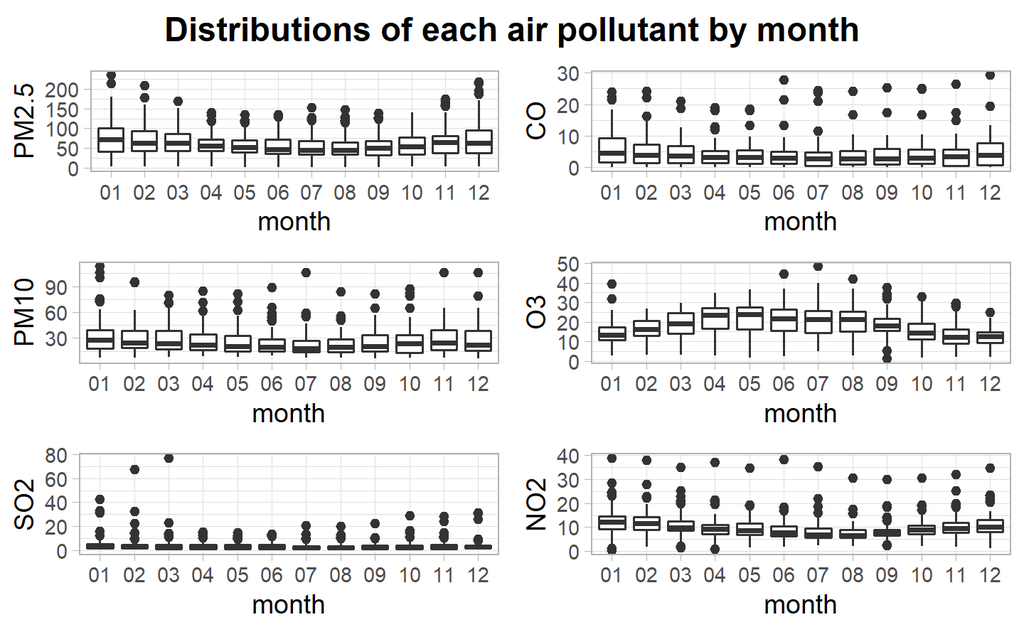

Now we visualized the top ten countries with the highest air pollution for each air pollutant.

Regarding SO2, we spotted that the level in Vietnam spiked between January to March and then plummeted in April.

Concerning NO2, Iran had a much higher level than the other countries and the level seemed to be stable all around the year.